# BDA502 - Introduction to Machine Learning: Term-Project

## NYC 311 Complaints

## Problem Statement

The people of New York use 311 system to report complaints about the non-emergency problems to local authorities. Various agencies in New York are assigned these problems. The Department of Housing Preservation and Development (HPD) of New York City is the agency that processes 311 complaints that are related to housing and buildings.

The number of 311 complaints coming to the Department of Housing Preservation and Development has been increasing significantly. Although these complaints are not necessarily urgent, the large volume of complaints and the sudden increase is impacting the overall efficiency of operations of the agency.

This project aims to tackle the requests that are related to housing and buildings which are addressed to HPD, and tries to offer solutions and recommendations to help the agency manage large volume of 311 complaints they are receiving every year.

This project will try to find answers and soutions supported by data and analytics to issues such as:

```
1. Which type of complaint should HPD focus on first?
2. For the specific type of complaint we have determined, which boroughs and locations (ZIP Codes) should be prioritized?
3. Is there an obvious relationship between the complaint type and any particular characteristic of the properties?
4. Can a predictive model be built for a future prediction of the possibility of complaints type at hand?
```

**- The Data:**

The data is from the Department of Housing Preservation and Development of New York City, in CSV format, obtained directly from NYC City Planning Website. Two different datasets are used from this source.

**311 complaint dataset:**

- All 311 Service Requests from 2010 to present. This information is automatically updated daily.
- Dataset consists of:

  ```
    - 22.4 Million rows, each are unique calls (requests) made to 311 Complaint Sevice.
    - 41 Columns
  ```

- More information of the data can be procured from the [main dataset documentation](https://data.cityofnewyork.us/Social-Services/311-Service-Requests-from-2010-to-Present/erm2-nwe9) page.
- Dataset will be acquired by using SODA API.
- For the purposes of the project, the complaints concerning the Housing Preservation and Development Agency (HPD) will be addressed. So, only the data that is related to the HPD will be downloaded and utilized. Also, data will be restricted to the limited number of relevant fields for computational purposes.

**PLUTO dataset for housing:**

- Extensive land use and geographic data at the 'tax lot' level in CSV format with more than seventy fields, for the five New York city boroughs: Bronx, Brooklyn, Manhattan, Queens, and Staten Island.
  - Only the part that is specific to the borough that my analysis is interested in will be used for the project. The specific borough will be selected according to prior analysis, so will be decided later.
  - More information about the dataset can be obtained from [here](https://www1.nyc.gov/site/planning/data-maps/open-data/dwn-pluto-mappluto.page).

*Note: The project is done under IBM Watson Studio Environment.*

**- Data Dictionary of 311 Complaints Dataset:**

```python
%matplotlib inline
import seaborn as sns
import matplotlib.pyplot as plt
import numpy as np
import pandas as pd
import scipy.stats as stats
from pandas.api.types import is_numeric_dtype
import datetime as dt
pd.options.mode.chained_assignment = None

from sklearn.linear_model import LinearRegression
from sklearn.preprocessing import PolynomialFeatures
from sklearn.preprocessing import MinMaxScaler
from sklearn.preprocessing import StandardScaler
from collections import Counter
from sklearn.model_selection import train_test_split
from scipy.stats import linregress
from sklearn.linear_model import LogisticRegression
from sklearn.neighbors import KNeighborsClassifier
from sklearn.svm import SVC, LinearSVC
from sklearn.naive_bayes import MultinomialNB
from sklearn.model_selection import GridSearchCV
from sklearn.metrics import classification_report, accuracy_score, confusion_matrix
from sklearn.tree import DecisionTreeClassifier
from sklearn.ensemble import RandomForestClassifier
from sklearn.metrics import recall_score
import operator
import warnings; warnings.simplefilter('ignore')
from pandas.io.gbq import read_gbq
from sklearn.model_selection import cross_val_score
from sklearn.model_selection import KFold
from sklearn.pipeline import Pipeline
```

```python
import types
from botocore.client import Config
import ibm_boto3

def __iter__(self): return 0

client_77d4082bfba146d2aaf797e2e0b98d5b = ibm_boto3.client(service_name='s3',
    ibm_api_key_id='KXdysmaZ2O7vIG2W83l8p2hhHS5Pek1gz6O-cwZFlq0y',
    ibm_auth_endpoint="https://iam.ng.bluemix.net/oidc/token",
    config=Config(signature_version='oauth'),
    endpoint_url='https://s3-api.us-geo.objectstorage.service.networklayer.com')

body = client_77d4082bfba146d2aaf797e2e0b98d5b.get_object(Bucket='nyc311complaintscapstoneprojectby-donotdelete-pr-v7dceuxtzaoaur', Key='311_SR_Data_Dictionary_2018.xlsx')['Body']
# add missing __iter__ method, so pandas accepts body as file-like object
if not hasattr(body, "__iter__"): body.__iter__ = types.MethodType( __iter__, body )

df_data_0 = pd.read_excel(body)
df_data_0
```

|  | Column Name | Description | Expected Values | Notes: |
| --- | --- | --- | --- | --- |
| 0 | Unique Key | Unique identifier of a Service Request (SR) in... | NaN | This is NOT the Service Request (SR) # provide... |
| 1 | Created Date | Date SR was created | Date in format MM/DD/YY HH:MM:SS AM/PM | NaN |
| 2 | Closed Date | Date SR was closed by responding agency | Date in format MM/DD/YY HH:MM:SS AM/PM | NaN |
| 3 | Agency | Acronym of responding City Government Agency | NaN | NaN |
| 4 | Agency Name | Full Agency name of responding City Government... | NaN | NaN |
| 5 | Complaint Type | This is the fist level of a hierarchy identify... | NaN | NaN |
| 6 | Descriptor | This is associated to the Complaint Type, and... | NaN | NaN |
| 7 | Status | Status of SR submitted | Assigned, Cancelled, Closed, Pending, + | Prior column indicates most frequent |
| 8 | Due Date | Date when responding agency is expected to upd... | Date in format MM/DD/YY HH:MM:SS AM/PM | NaN |
| 9 | Resolution Action Updated Date | Date when responding agency last updated the SR. | Date in format MM/DD/YY HH:MM:SS AM/PM | NaN |
| 10 | Resolution Description | Describes the last action taken on the SR by t... | NaN | NaN |
| 11 | Location Type | Describes the type of location used in the add... | NaN | NaN |
| 12 | Incident Zip | Incident location zip code, provided by geo va... | NaN | NaN |
| 13 | Incident Address | House number of incident address provided by s... | NaN | NaN |
| 14 | Street Name | Street name of incident address provided by th... | NaN | NaN |
| 15 | Cross Street 1 | First Cross street based on the geo validated ... | NaN | NaN |
| 16 | Cross Street 2 | Second Cross Street based on the geo validated... | NaN | NaN |
| 17 | Intersection Street 1 | First intersecting street based on geo validat... | NaN | NaN |
| 18 | Intersection Street 2 | Second intersecting street based on geo valida... | NaN | NaN |
| 19 | Address Type | Type of incident location information available. | Values: Address; Block face; Intersection; Lat... | NaN |
| 20 | City | City of the incident location provided by geov... | NaN | NaN |
| 21 | Landmark | If the incident location is identified as a La... | NaN | NaN |
| 22 | Facility Type | If available, this field describes the type of... | NaN | NaN |
| 23 | Community Board | Provided by geovalidation. | NaN | NaN |
| 24 | BBL | Borough Block and Lot, provided by geovalidati... | NaN | NaN |
| 25 | Borough | Provided by the submitter and confirmed by geo... | NaN | NaN |
| 26 | X Coordinate (State Plane) | Geo validated, X coordinate of the incident lo... | NaN | NaN |
| 27 | Y Coordinate (State Plane) | Geo validated, Y coordinate of the incident l... | NaN | NaN |
| 28 | Open_Data_Channel_Type | Indicates how the SR was submitted to 311. i.... | PHONE, ONLINE, MOBILE, OTHER and UNKNOWN | Phone - submitted by a 311 call center agent o... |
| 29 | Latitude | Geo based Lat of the incident location | NaN | NaN |
| 30 | Longitude | Geo based Long of the incident location | NaN | NaN |
| 31 | Location | Combination of the geo based lat & long of the... | NaN | NaN |
| 32 | Park Facility Name | If the incident location is a Parks Dept facil... | NaN | NaN |
| 33 | Park Borough | The borough of incident if it is a Parks Dept ... | NaN | NaN |
| 34 | Vehicle Type | If the incident is a taxi, this field describe... | Car Service; Commuter Van; Green Taxi | NaN |
| 35 | Taxi Company Borough | If the incident is identified as a taxi, this ... | NaN | NaN |
| 36 | Taxi Pick Up Location | If the incident is identified as a taxi, this ... | Grand Central Station; Intersection; JKF Airpo... | NaN |
| 37 | Bridge Highway Name | If the incident is identified as a Bridge/High... | NaN | NaN |
| 38 | Bridge Highway Direction | If the incident is identified as a Bridge/High... | NaN | NaN |
| 39 | Road Ramp | If the incident location was Bridge/Highway th... | Roadway; Ramp | NaN |
| 40 | Bridge Highway Segment | Additional information on the section of the B... | NaN | NaN |

## EDA of 311 Complaints

```python
body = client_77d4082bfba146d2aaf797e2e0b98d5b.get_object(Bucket='nyc311complaintscapstoneprojectby-donotdelete-pr-v7dceuxtzaoaur', Key = '311 HPD.csv')['Body']
# add missing __iter__ method, so pandas accepts body as file-like object
if not hasattr(body, "__iter__"): body.__iter__ = types.MethodType( __iter__, body )

df = pd.read_csv(body, parse_dates=['created_date', 'closed_date'])
df.head()
```

|  | created_date | unique_key | complaint_type | incident_zip | incident_address | street_name | address_type | city | resolution_description | borough | latitude | longitude | closed_date | location_type | status |
| --- | --- | --- | --- | --- | --- | --- | --- | --- | --- | --- | --- | --- | --- | --- | --- |
| 0 | 2020-03-28 17:48:57 | 45910245 | HEAT/HOT WATER | 10002.0 | 85 RIVINGTON STREET | RIVINGTON STREET | ADDRESS | NEW YORK | The complaint you filed is a duplicate of a co... | MANHATTAN | 40.720266 | -73.989001 | NaT | RESIDENTIAL BUILDING | Open |
| 1 | 2020-03-28 18:51:16 | 45910916 | HEAT/HOT WATER | 10452.0 | 1425 DR M L KING JR BOULEVARD | DR M L KING JR BOULEVARD | ADDRESS | BRONX | The complaint you filed is a duplicate of a co... | BRONX | 40.843456 | -73.924705 | NaT | RESIDENTIAL BUILDING | Open |
| 2 | 2020-03-28 20:07:59 | 45910937 | WATER LEAK | 11208.0 | 126 GRANT AVENUE | GRANT AVENUE | ADDRESS | BROOKLYN | The following complaint conditions are still o... | BROOKLYN | 40.687957 | -73.868316 | NaT | RESIDENTIAL BUILDING | Open |
| 3 | 2020-03-28 20:19:59 | 45911252 | DOOR/WINDOW | 11237.0 | 65 WYCKOFF AVENUE | WYCKOFF AVENUE | ADDRESS | BROOKLYN | The following complaint conditions are still o... | BROOKLYN | 40.705539 | -73.921178 | NaT | RESIDENTIAL BUILDING | Open |
| 4 | 2020-03-28 15:49:50 | 45911266 | HEAT/HOT WATER | 10462.0 | 2040 BRONXDALE AVENUE | BRONXDALE AVENUE | ADDRESS | BRONX | The complaint you filed is a duplicate of a co... | BRONX | 40.850795 | -73.866537 | NaT | RESIDENTIAL BUILDING | Open |

```python
df.shape
```

```
(6076774, 15)
```

```python
df.info()
```

```
<class 'pandas.core.frame.DataFrame'>
RangeIndex: 6076774 entries, 0 to 6076773
Data columns (total 15 columns):
created_date              datetime64[ns]
unique_key                int64
complaint_type            object
incident_zip              float64
incident_address          object
street_name               object
address_type              object
city                      object
resolution_description    object
borough                   object
latitude                  float64
longitude                 float64
closed_date               datetime64[ns]
location_type             object
status                    object
dtypes: datetime64[ns](2), float64(3), int64(1), object(9)
memory usage: 695.4+ MB
```

### Complaint Types

**Which complaints should be attended?**

```python
print(df["complaint_type"].unique())
```

```
['HEAT/HOT WATER' 'WATER LEAK' 'DOOR/WINDOW' 'PLUMBING' 'PAINT/PLASTER'
 'UNSANITARY CONDITION' 'ELECTRIC' 'FLOORING/STAIRS' 'GENERAL' 'SAFETY'
 'OUTSIDE BUILDING' 'APPLIANCE' 'ELEVATOR' 'General'
 'Unsanitary Condition' 'HPD Literature Request' 'HEATING'
 'PAINT - PLASTER' 'Safety' 'Electric' 'Appliance' 'GENERAL CONSTRUCTION'
 'NONCONST' 'CONSTRUCTION' 'AGENCY' 'STRUCTURAL' 'VACANT APARTMENT'
 'Outside Building' 'Plumbing' 'Mold']
```

```python
complaint_counts = pd.DataFrame()
complaint_counts = df["complaint_type"].value_counts()
complaint_counts
```

```
HEAT/HOT WATER            1294681
HEATING                    887869
PLUMBING                   715039
GENERAL CONSTRUCTION       500863
UNSANITARY CONDITION       457373
PAINT - PLASTER            361257
PAINT/PLASTER              349130
ELECTRIC                   308858
NONCONST                   260890
DOOR/WINDOW                207659
WATER LEAK                 195640
GENERAL                    153364
FLOORING/STAIRS            138635
APPLIANCE                  114137
HPD Literature Request      52830
SAFETY                      52262
OUTSIDE BUILDING             7197
ELEVATOR                     6870
Unsanitary Condition         5499
CONSTRUCTION                 5078
General                      1163
Safety                        424
STRUCTURAL                     16
Plumbing                       11
AGENCY                          9
VACANT APARTMENT                8
Outside Building                6
Appliance                       4
Electric                        1
Mold                            1
Name: complaint_type, dtype: int64
```

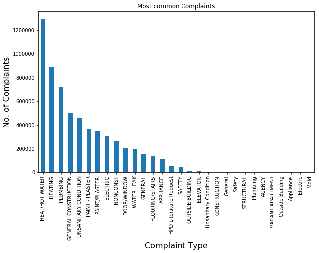

```python
ax = complaint_counts.plot(kind='bar', figsize=(10, 6), title = 'Most common Complaints')
ax.set_xlabel('Complaint Type', fontsize = 16)
ax.set_ylabel('No. of Complaints', fontsize = 16)
```

We can clearly see that HEAT/HOT WATER is by far the most common problem in NYC concerning housing and buildings. So, The agency's priority should be focusing on HEAT/HOT WATER.

From the domain knowledge gathered from experts, we know that there's a profound similarity between HEAT/HOT WATER and HEATING. From the accumulated general knowledge of the data, we also know that, as of year 2014, HEATING label has been changed as HEATING/HOT WATER. So, bringing these two labels together analyzing them collectively is a good idea.

Similar issue can be observed with "PAINT - PLASTER" and "PAINT/PLASTER" labels, too. So, I'll bring these two together as well.

```python
df['complaint_type'] = np.where(df['complaint_type']=='HEATING','HEAT/HOT WATER',df['complaint_type'])
df['complaint_type'] = np.where(df['complaint_type']=='PAINT - PLASTER','PAINT/PLASTER',df['complaint_type'])
complaint_counts1 = df["complaint_type"].value_counts()
complaint_counts1.head(5)
```

```
HEAT/HOT WATER          2182550
PLUMBING                 715039
PAINT/PLASTER            710387
GENERAL CONSTRUCTION     500863
UNSANITARY CONDITION     457373
Name: complaint_type, dtype: int64
```

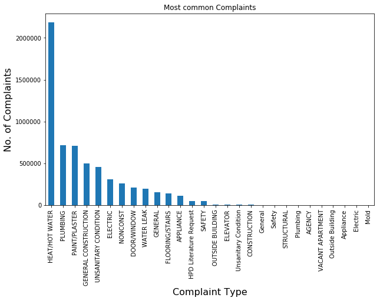

```python
complaint_counts1 = df["complaint_type"].value_counts()
ax = complaint_counts1.plot(kind='bar', figsize=(10, 6), title = 'Most common Complaints')
ax.set_xlabel('Complaint Type', fontsize = 16)
ax.set_ylabel('No. of Complaints', fontsize = 16)
```

We have good understanding of which complaint type 311 Service is dealing with most. Now, let's look at the status of the cases; "open", "closed" and "in progress".

```python
df['Open'] = (df['status'] == 'Open').astype(int)
df['Closed'] =  (df['status'] == 'Closed').astype(int)
df['In Progress'] =  (df['status'] == 'In Progress').astype(int)
df_complaints = df.groupby(['complaint_type'])
```

```python
df_status = pd.DataFrame()
df_status['Open'] = df_complaints['Open'].sum(axis = 1)
df_status['Closed'] = df_complaints['Closed'].sum(axis = 1)
df_status['In Progress'] = df_complaints['In Progress'].sum(axis = 1)
status_total = pd.DataFrame(df_status.sum(axis = 0)).transpose()
status_total.index = ['Total']
status_total
```

|  | Open | Closed | In Progress |
| --- | --- | --- | --- |
| Total | 134501 | 5941904 | 363 |

```python
df_status = df_status.reindex(columns = ["Closed", "Open", "In Progress"])
df_status['Total'] = df_status['Open'] + df_status['Closed'] + df_status['In Progress']
df_status.sort_values(by=['Open'], inplace=True, ascending=False)
df_status
```

| complaint_type | Closed | Open | In Progress | Total |
| --- | --- | --- | --- | --- |
| GENERAL CONSTRUCTION | 471240 | 29623 | 0 | 500863 |
| PLUMBING | 688565 | 26474 | 0 | 715039 |
| PAINT/PLASTER | 686610 | 23777 | 0 | 710387 |
| HEAT/HOT WATER | 2166839 | 15709 | 0 | 2182548 |
| NONCONST | 245612 | 15278 | 0 | 260890 |
| ELECTRIC | 299554 | 9304 | 0 | 308858 |
| APPLIANCE | 110203 | 3934 | 0 | 114137 |
| UNSANITARY CONDITION | 454288 | 3085 | 0 | 457373 |
| DOOR/WINDOW | 206125 | 1534 | 0 | 207659 |
| GENERAL | 151933 | 1431 | 0 | 153364 |
| WATER LEAK | 194216 | 1424 | 0 | 195640 |
| FLOORING/STAIRS | 137530 | 1105 | 0 | 138635 |
| HPD Literature Request | 51750 | 1076 | 0 | 52826 |
| SAFETY | 51911 | 351 | 0 | 52262 |
| CONSTRUCTION | 4812 | 266 | 0 | 5078 |
| ELEVATOR | 6804 | 66 | 0 | 6870 |
| OUTSIDE BUILDING | 7138 | 59 | 0 | 7197 |
| VACANT APARTMENT | 3 | 5 | 0 | 8 |
| Unsanitary Condition | 5253 | 0 | 246 | 5499 |
| Safety | 405 | 0 | 19 | 424 |
| STRUCTURAL | 16 | 0 | 0 | 16 |
| AGENCY | 9 | 0 | 0 | 9 |
| Plumbing | 11 | 0 | 0 | 11 |
| Outside Building | 6 | 0 | 0 | 6 |
| General | 1068 | 0 | 95 | 1163 |
| Electric | 1 | 0 | 0 | 1 |
| Appliance | 2 | 0 | 2 | 4 |
| Mold | 0 | 0 | 1 | 1 |

We can see that HPD attends "Unsanitary Condition" matters in a more immediate manner.

**Number of open (unattended) complaints:**

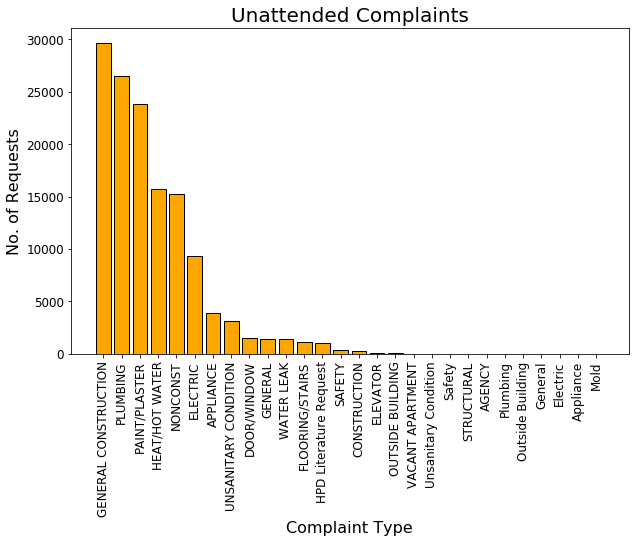

```python
x = np.arange(len(df_status.index))
Open = df_status['Open'].values
plt.figure(figsize = (10, 6))
plt.bar(x, Open, color = 'orange', edgecolor = 'black', label = 'Open')
plt.xticks(x, df_status.index, rotation = 'vertical', fontsize = 12)
plt.yticks(fontsize = 12)
plt.xlabel('Complaint Type', fontsize = 16)
plt.ylabel('No. of Requests', fontsize = 16)
plt.title('Unattended Complaints', fontsize = 20)
plt.show()
```

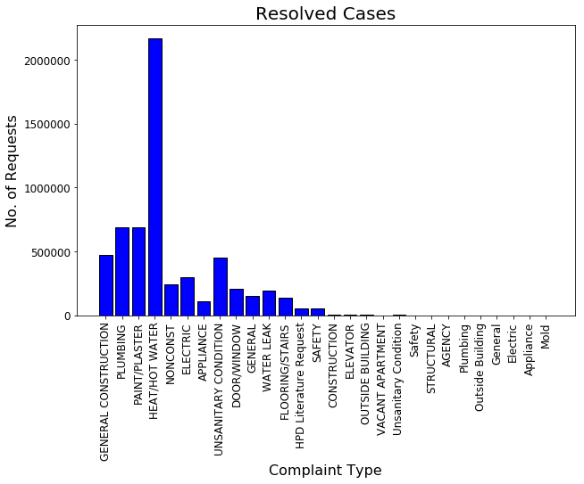

```python
x1 = np.arange(len(df_status.index))
Open = df_status['Closed'].values
plt.figure(figsize = (10, 6))
plt.bar(x, Open, color = 'blue', edgecolor = 'black', label = 'Closed')
plt.xticks(x1, df_status.index, rotation = 'vertical', fontsize = 12)
plt.yticks(fontsize = 12)
plt.xlabel('Complaint Type', fontsize = 16)
plt.ylabel('No. of Requests', fontsize = 16)
plt.title('Resolved Cases', fontsize = 20)
plt.show()
```

From the visualization above we can see that;

- General Construction complaints have not been attended properly, while there are most open cases of this category.
- Plumbing category displays a similar situation in terms of open case ratio.
- The agency has done a relatively good job addressing Heat/Hot Water complaints. However, this category still needs to be attended because of the high volume of cases.

**Although, the Heat/Hot Water category has more complaints over all, the General Construction and Plumbing categories have more complaints un-attended. So, I'd recommend the agency to tackle these three categories as a priority.**

```python
complaint_df = df.loc[(df['complaint_type'] == "HEAT/HOT WATER") | (df['complaint_type'] == "GENERAL CONSTRUCTION") | (df['complaint_type'] == "PLUMBING")]
complaint_df.shape
```

```
(3398452, 18)
```

### Boroughs and Locations

**What Areas Should the Agency Focus On?**

```python
complaint_df["borough"].value_counts()
```

```
BROOKLYN         922187
BRONX            907550
MANHATTAN        603823
Unspecified      565491
QUEENS           359807
STATEN ISLAND     39594
Name: borough, dtype: int64
```

There are huge number of "Unspecified" Boroughs in the data. We need to assign boroughs to the unspecified instances. We can do it by classification using ZIP codes.

```python
complaint_df.isnull().sum()
```

```
created_date                  0
unique_key                    0
complaint_type                0
incident_zip              23144
incident_address              1
street_name                   1
address_type              21399
city                      22950
resolution_description      455
borough                       0
latitude                  23135
longitude                 23135
closed_date               68372
location_type                 0
status                        0
Open                          0
Closed                        0
In Progress                   0
dtype: int64
```

There's one observation where the Street Name has no input. Since, it's only one instance and won't effect my analysis, I decided to remove that particular instance.

```python
complaint_df = complaint_df.dropna(how='any', subset=['street_name'])
complaint_df.isnull().sum()
```

```
created_date                  0
unique_key                    0
complaint_type                0
incident_zip              23143
incident_address              0
street_name                   0
address_type              21398
city                      22949
resolution_description      455
borough                       0
latitude                  23134
longitude                 23134
closed_date               68372
location_type                 0
status                        0
Open                          0
Closed                        0
In Progress                   0
dtype: int64
```

```python
complaint_df['incident_zip'].unique()
```

```
array([10002., 10452., 10462., 11366., 10466., 11355., 10463., 10467.,
       11217., 10033., 11225., 10457., 10456., 11211., 11214., 10025.,
       11238., 11374., 11208., 10470., 10032., 10454., 11209., 10019.,
       11230., 10461., 11235., 10017., 10473., 10458., 10040., 10472.,
       10460., 10468., 11249., 10031., 11203., 10034., 11367., 10471.,
       10469., 10026., 11232., 11354., 10036., 11229., 10305., 10474.,
       11237., 11207., 11234., 10010., 11434., 11372., 11419., 10453.,
       10455., 11205., 11375., 10451., 11219., 10027., 11423., 11212.,
       11222., 11216., 11432., 11226., 11412., 11101., 11415., 10009.,
       10459., 11358., 10016., 11417., 10003., 10465., 10001., 11220.,
       10029., 11210., 10023., 10301., 11218., 10065., 11691., 11377.,
       10128., 11694., 11233., 10013., 11422., 10012., 11385., 11223.,
       11368., 11104., 11102., 10035., 11433., 11213., 10024., 11418.,
       10309., 10028., 10022., 11204., 10030., 11224., 10304., 11221.,
       10303., 10075., 11206., 10037., 11373., 11236., 11435., 10314.,
       11201., 11231., 10039., 11103., 10011., 11429., 11420., 10312.,
       11426., 10021., 11413., 11436., 11379., 11239., 11421.,    nan,
       11364., 11228., 11105., 11411., 11378., 11692., 11356., 10014.,
       11215., 11369., 10302., 11427., 11106., 10004., 11428., 10475.,
       10310., 11416., 11361., 11693., 10306., 11414., 10307., 11357.,
       11365., 10464., 10018., 10308., 11370., 11040., 10038., 10005.,
       11362., 10006., 10044., 11363., 11360., 10007., 10121., 11004.,
       11697., 10112., 10020., 11001., 10069., 10280., 11243., 11109.,
       10282., 11005., 11430., 10803., 10129., 10041., 10103., 10162.,
       10106., 10279., 10045., 12345., 10169.])
```

We have 23143 NaN entries in 'incident_zip' column. First, I'd like to fill them using **interpolation**.

```python
zip_pairs_known = complaint_df[['street_name','incident_zip']][(complaint_df.incident_zip.isnull() == False)]
zip_pairs_unknown = complaint_df[['street_name','incident_zip']][(complaint_df.incident_zip.isnull() == True)]
zip_pairs_known.shape, zip_pairs_unknown.shape
```

```
((3375308, 2), (23143, 2))
```

```python
zip_bestpair = zip_pairs_known.groupby('street_name').agg(lambda x: Counter(x.incident_zip).most_common(1)[0][0])
zip_bestpair.head(10)
```

| street_name | incident_zip |
| --- | --- |
| 1 AVENUE | 10029.0 |
| 1 COURT | 11223.0 |
| 1 PLACE | 11231.0 |
| 1 STREET | 11215.0 |
| 10 AVENUE | 10019.0 |
| 10 STREET | 11215.0 |
| 100 AVENUE | 11429.0 |
| 100 DRIVE | 11429.0 |
| 100 ROAD | 11429.0 |
| 100 STREET | 11368.0 |

```python
zip_dict = zip_bestpair.to_dict()
```

```python
brgh_zips = complaint_df.street_name.map(zip_dict['incident_zip'])
len(complaint_df.incident_zip) == len(brgh_zips)
```

```
True
```

```python
brgh_zips.isnull().value_counts()
```

```
False    3398035
True         416
Name: street_name, dtype: int64
```

Entries with NaN value under 'incident_zip' field has dropped to 416 from 23143. Not bad at all...

```python
complaint_df.incident_zip = brgh_zips
```

We now have a cleaner data with minimum loss. We can perform a similar interpolation in order to replace 'Unspecified Boroughs' by using known information.

```python
known_pairs = complaint_df[['borough','incident_zip']][(complaint_df.borough != 'Unspecified') & (complaint_df.incident_zip.isnull() == False)]
known_pairs.head()
```

|  | borough | incident_zip |
| --- | --- | --- |
| 0 | MANHATTAN | 10002.0 |
| 1 | BRONX | 10453.0 |
| 4 | BRONX | 10462.0 |
| 5 | QUEENS | 11432.0 |
| 6 | BRONX | 10466.0 |

```python
unknown_pairs = complaint_df[['borough','incident_zip']][(complaint_df.borough == 'Unspecified') & (complaint_df.incident_zip.isnull() == False)]
unknown_pairs.head()
```

|  | borough | incident_zip |
| --- | --- | --- |
| 6215 | Unspecified | 10304.0 |
| 234549 | Unspecified | 10032.0 |
| 234550 | Unspecified | 11210.0 |
| 234551 | Unspecified | 11210.0 |
| 234552 | Unspecified | 11235.0 |

```python
 known_pairs.shape, unknown_pairs.shape
```

```
((2832717, 2), (565318, 2))
```

```python
known_pairs.borough.value_counts()
```

```
BROOKLYN         922133
BRONX            907504
MANHATTAN        603797
QUEENS           359722
STATEN ISLAND     39561
Name: borough, dtype: int64
```

We now have a dataframe containing all boroughs with valid entries along with the corresponding Zip Code. The 'known pairs' will help us interpolate the data in the 'borough' field.

```python
best_paired = known_pairs.groupby('incident_zip').agg(lambda x: Counter(x.borough).most_common(1)[0][0])
best_paired.head(10)
```

| incident_zip | borough |
| --- | --- |
| 10001.0 | MANHATTAN |
| 10002.0 | MANHATTAN |
| 10003.0 | MANHATTAN |
| 10004.0 | MANHATTAN |
| 10005.0 | MANHATTAN |
| 10006.0 | MANHATTAN |
| 10007.0 | MANHATTAN |
| 10009.0 | MANHATTAN |
| 10010.0 | MANHATTAN |
| 10011.0 | MANHATTAN |

```python
paired_dict = best_paired.to_dict()
boroughs_cleaned = complaint_df.incident_zip.map(paired_dict['borough'])
len(complaint_df.borough) == len(boroughs_cleaned)
```

```
True
```

```python
boroughs_cleaned.value_counts()
```

```
BROOKLYN         1106447
BRONX            1105587
MANHATTAN         737179
QUEENS            408605
STATEN ISLAND      40217
Name: incident_zip, dtype: int64
```

```python
complaint_df.borough = boroughs_cleaned
```

```python
complaint_df["borough"].value_counts()
```

```
BROOKLYN         1106447
BRONX            1105587
MANHATTAN         737179
QUEENS            408605
STATEN ISLAND      40217
Name: borough, dtype: int64
```

```python
complaint_df.shape
```

```
(3398451, 18)
```

A pretty good improvement. Now we can move on...

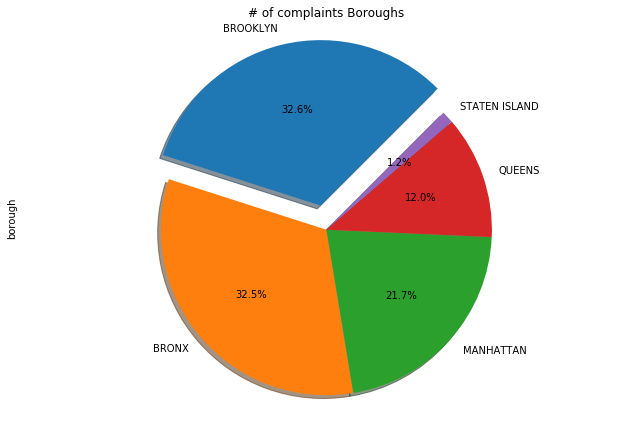

```python
complaint_df['borough'].value_counts().plot(kind = 'pie',autopct='%1.1f%%',
                        explode = (0.15, 0, 0, 0, 0), startangle = 45, shadow = True, figsize = (9,6))

plt.axis('equal')
plt.title('# of complaints Boroughs')
plt.tight_layout()
plt.show()
```

```
(-74.2531150361251, -73.70078552010422, 40.49934009852311, 40.912868795316655)
```

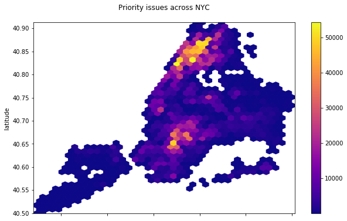

```python
complaint_df.plot(kind = 'hexbin', x = 'longitude', y = 'latitude', colormap = 'plasma',
                  gridsize = 40, mincnt = 1, title = 'Priority issues across NYC\n',
                  figsize=(10,6)).axis('equal')
```

Both the Pie Chart and the Map show us Brooklyn and Bronx are the two boroughs with highest number of instances concerning Heat/Hot Water, General Construction and Plumbing.

To summarize the key takeaways up until now:

- Heat/Hot Water, General Construction and Plumbing are the complaint types which need to be attained first.
- The agency should focus on two boroughs, Bronx and Brooklyn, for these priority incidents.

*For the purposes of this project I will continue dealing with Heat/Hot Water complaints in Brooklyn as this combination has the most incidents.*

```python
df_Brooklyn = complaint_df[complaint_df['borough']=='BROOKLYN']
df_Brook_Heat = df_Brooklyn[df_Brooklyn['complaint_type'] == 'HEAT/HOT WATER']
df_Brook_Heat.shape
```

```
(672767, 18)
```

```
(-74.24411785406106, -73.72885604259504, 40.50229374290755, 40.912868795316655)
```

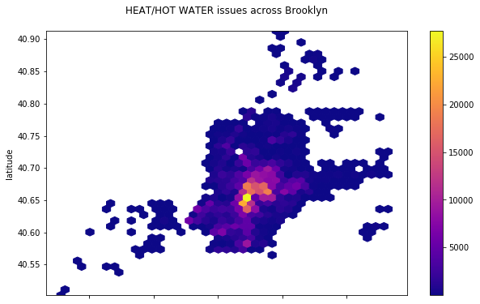

```python
df_Brook_Heat.plot(kind = 'hexbin', x = 'longitude', y = 'latitude', colormap = 'plasma',
                  gridsize = 40, mincnt = 1, title = 'HEAT/HOT WATER issues across Brooklyn\n',
                  figsize=(10,6)).axis('equal')
```

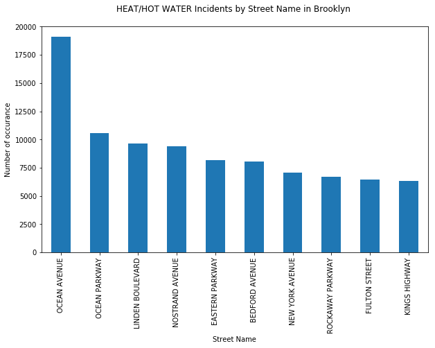

```python
df_Brook_Heat["street_name"].value_counts().head(10).plot(kind = 'bar', figsize=(10, 6))

plt.xlabel('Street Name')
plt.ylabel('Number of occurance')
plt.title('HEAT/HOT WATER Incidents by Street Name in Brooklyn \n')

plt.show()
```

### Relationship Between Complaints and Building Characteristics

**Now that we have defined and visualized the Heat/Hot Water instances in Brooklyn, we can investigate if these complaints have any relationship with the characteristics of the houses or buildings...**

```python
df_Brook_Heat['location_type'].unique()
```

```
array(['RESIDENTIAL BUILDING'], dtype=object)
```

All complaints at hand come from Residential Buildings.

Here we need to bring Pluto dataset which will give us insights about the characteristics on buildings into the picture.

```python
body = client_77d4082bfba146d2aaf797e2e0b98d5b.get_object(Bucket='nyc311complaintscapstoneprojectby-donotdelete-pr-v7dceuxtzaoaur',Key='pluto_20v1.csv')['Body']
# add missing __iter__ method, so pandas accepts body as file-like object
if not hasattr(body, "__iter__"): body.__iter__ = types.MethodType( __iter__, body )

df_data_1 = pd.read_csv(body, low_memory=False)
df_data_1.head()
```

|  | borough | block | lot | cd | ct2010 | cb2010 | schooldist | council | zipcode | firecomp | ... | dcasdate | zoningdate | landmkdate | basempdate | masdate | polidate | edesigdate | geom | dcpedited | notes |
| --- | --- | --- | --- | --- | --- | --- | --- | --- | --- | --- | --- | --- | --- | --- | --- | --- | --- | --- | --- | --- | --- |
| 0 | BK | 834 | 46 | 307.0 | 106.0 | 2001.0 | 20.0 | 38.0 | 11220.0 | L114 | ... | NaN | NaN | NaN | NaN | NaN | NaN | NaN | 0106000020E61000000100000001030000000100000005... | NaN | NaN |
| 1 | QN | 4042 | 106 | 407.0 | 929.0 | 3000.0 | 25.0 | 19.0 | 11356.0 | E297 | ... | NaN | NaN | NaN | NaN | NaN | NaN | NaN | 0106000020E61000000100000001030000000100000007... | NaN | NaN |
| 2 | BK | 4679 | 17 | 317.0 | 866.0 | 3002.0 | 18.0 | 41.0 | 11203.0 | L174 | ... | NaN | NaN | NaN | NaN | NaN | NaN | NaN | 0106000020E61000000100000001030000000100000006... | NaN | NaN |
| 3 | BK | 7831 | 6 | 318.0 | 676.0 | 1002.0 | 22.0 | 46.0 | 11234.0 | L159 | ... | NaN | NaN | NaN | NaN | NaN | NaN | NaN | 0106000020E61000000100000001030000000100000005... | NaN | NaN |
| 4 | BK | 7831 | 7 | 318.0 | 676.0 | 1002.0 | 22.0 | 46.0 | 11234.0 | L159 | ... | NaN | NaN | NaN | NaN | NaN | NaN | NaN | 0106000020E61000000100000001030000000100000005... | NaN | NaN |

5 rows × 99 columns

```python
pl_BK = df_data_1[df_data_1.borough == "BK"]
pl_BK.shape
```

```
(277013, 99)
```

```python
pl_BK.columns
```

```
Index(['borough', 'block', 'lot', 'cd', 'ct2010', 'cb2010', 'schooldist',
       'council', 'zipcode', 'firecomp', 'policeprct', 'healtharea',
       'sanitboro', 'sanitsub', 'address', 'zonedist1', 'zonedist2',
       'zonedist3', 'zonedist4', 'overlay1', 'overlay2', 'spdist1', 'spdist2',
       'spdist3', 'ltdheight', 'splitzone', 'bldgclass', 'landuse',
       'easements', 'ownertype', 'ownername', 'lotarea', 'bldgarea', 'comarea',
       'resarea', 'officearea', 'retailarea', 'garagearea', 'strgearea',
       'factryarea', 'otherarea', 'areasource', 'numbldgs', 'numfloors',
       'unitsres', 'unitstotal', 'lotfront', 'lotdepth', 'bldgfront',
       'bldgdepth', 'ext', 'proxcode', 'irrlotcode', 'lottype', 'bsmtcode',
       'assessland', 'assesstot', 'exempttot', 'yearbuilt', 'yearalter1',
       'yearalter2', 'histdist', 'landmark', 'builtfar', 'residfar', 'commfar',
       'facilfar', 'borocode', 'bbl', 'condono', 'tract2010', 'xcoord',
       'ycoord', 'latitude', 'longitude', 'zonemap', 'zmcode', 'sanborn',
       'taxmap', 'edesignum', 'appbbl', 'appdate', 'plutomapid', 'version',
       'sanitdistrict', 'healthcenterdistrict', 'firm07_flag', 'pfirm15_flag',
       'rpaddate', 'dcasdate', 'zoningdate', 'landmkdate', 'basempdate',
       'masdate', 'polidate', 'edesigdate', 'geom', 'dcpedited', 'notes'],
      dtype='object')
```

Selecting relevant columns:

```python
pl_BK = pl_BK[["address", "bldgarea", "bldgdepth", "numfloors", "yearbuilt", "resarea"]]
pl_BK.shape
```

```
(277013, 6)
```

```python
pl_BK.head()
```

|  | address | bldgarea | bldgdepth | numfloors | yearbuilt | resarea |
| --- | --- | --- | --- | --- | --- | --- |
| 0 | 5524 8 AVENUE | 3648.0 | 52.0 | 3.0 | 1931.0 | 2598.0 |
| 2 | 230 EAST 54 STREET | 2814.0 | 67.0 | 2.0 | 1920.0 | 2814.0 |
| 3 | 5109 AVENUE L | 973.0 | 27.0 | 2.0 | 1920.0 | 973.0 |
| 4 | 5107 AVENUE L | 938.0 | 27.0 | 2.0 | 1920.0 | 938.0 |
| 5 | 5105 AVENUE L | 938.0 | 27.0 | 2.0 | 1920.0 | 938.0 |

**In order to understand the relationship between complaint type and the characteristic of a building, we need to handle instances according to their addresses.**

For that, we need to create a new dataframe which has addresses and the number of incidents that has occured in that address.

```python
df_Brook_Heat["incident_address"].value_counts().head()
```

```
9511 SHORE ROAD          5450
1711 FULTON STREET       2891
2750 HOMECREST AVENUE    2866
109 NORTH    7 STREET    1731
170 HAWTHORNE STREET     1562
Name: incident_address, dtype: int64
```

```python
n_inc_adrsBK = df_Brook_Heat[["incident_address", "complaint_type"]]
n_inc_adrsBK = n_inc_adrsBK.groupby(["incident_address"])
n_inc_adrsBK = n_inc_adrsBK.count()
n_inc_adrsBK.columns = ["num_complaints"]
n_inc_adrsBK.sort_values(by=['num_complaints'], inplace=True, ascending=False)
n_inc_adrsBK.head()
```

| incident_address | num_complaints |
| --- | --- |
| 9511 SHORE ROAD | 5450 |
| 1711 FULTON STREET | 2891 |
| 2750 HOMECREST AVENUE | 2866 |
| 109 NORTH 7 STREET | 1731 |
| 170 HAWTHORNE STREET | 1562 |

Now we have a dataframe with addresses as indexes and the number of calls concerning HEAT/HOT WATER problems.

*As in this dataframe each address represents a building, in order to merge and compare buildings; we need to drop duplicate addresses from the PLUTO data since they represent properties (units), not buildings.*

```python
pl_BK.drop_duplicates(subset="address", keep=False, inplace=True)
```

```python
buildings_df = pd.merge(n_inc_adrsBK, pl_BK, left_index=True, right_on="address", how="right")
buildings_df.info()
```

```
<class 'pandas.core.frame.DataFrame'>
Int64Index: 270633 entries, 0 to 859169
Data columns (total 7 columns):
num_complaints    35230 non-null float64
address           270633 non-null object
bldgarea          270632 non-null float64
bldgdepth         270624 non-null float64
numfloors         270624 non-null float64
yearbuilt         270633 non-null float64
resarea           262704 non-null float64
dtypes: float64(6), object(1)
memory usage: 16.5+ MB
```

```python
buildings_df['num_complaints'].replace(np.nan, 0.0, inplace = True)
buildings_df = buildings_df[buildings_df.yearbuilt >= 1820]
buildings_df["Age"] = 2020 - buildings_df["yearbuilt"]
buildings_df = buildings_df[["num_complaints", "bldgarea", "bldgdepth", "Age","numfloors", "resarea"]]
buildings_df.head(15)
```

|  | num_complaints | bldgarea | bldgdepth | Age | numfloors | resarea |
| --- | --- | --- | --- | --- | --- | --- |
| 0 | 0.0 | 3648.0 | 52.0 | 89.0 | 3.0 | 2598.0 |
| 2 | 0.0 | 2814.0 | 67.0 | 100.0 | 2.0 | 2814.0 |
| 3 | 0.0 | 973.0 | 27.0 | 100.0 | 2.0 | 973.0 |
| 4 | 0.0 | 938.0 | 27.0 | 100.0 | 2.0 | 938.0 |
| 5 | 0.0 | 938.0 | 27.0 | 100.0 | 2.0 | 938.0 |
| 6 | 0.0 | 938.0 | 27.0 | 100.0 | 2.0 | 938.0 |
| 7 | 0.0 | 986.0 | 27.0 | 100.0 | 2.0 | 986.0 |
| 8 | 0.0 | 740.0 | 28.0 | 100.0 | 1.0 | 740.0 |
| 9 | 0.0 | 1800.0 | 36.0 | 65.0 | 2.0 | 1440.0 |
| 12 | 0.0 | 1540.0 | 40.0 | 80.0 | 1.0 | 880.0 |
| 14 | 0.0 | 1288.0 | 54.0 | 65.0 | 1.0 | 1288.0 |
| 15 | 1.0 | 3360.0 | 84.0 | 110.0 | 2.0 | 1680.0 |
| 16 | 0.0 | 2330.0 | 30.0 | 119.0 | 3.0 | 2330.0 |
| 19 | 2.0 | 3443.0 | 53.0 | 65.0 | 2.0 | 2504.0 |
| 20 | 0.0 | 3443.0 | 53.0 | 65.0 | 2.0 | 2504.0 |

```python
buildings_df.describe()
```

|  | num_complaints | bldgarea | bldgdepth | Age | numfloors | resarea |
| --- | --- | --- | --- | --- | --- | --- |
| count | 264605.000000 | 2.646040e+05 | 264605.000000 | 264605.000000 | 264605.000000 | 2.623310e+05 |
| mean | 1.922107 | 5.413060e+03 | 52.132372 | 88.641250 | 2.425763 | 3.773464e+03 |
| std | 21.672976 | 3.185202e+04 | 33.463740 | 30.034935 | 1.175048 | 1.912705e+04 |
| min | 0.000000 | 0.000000e+00 | 0.000000 | 0.000000 | 0.000000 | 0.000000e+00 |
| 25% | 0.000000 | 1.760750e+03 | 40.000000 | 80.000000 | 2.000000 | 1.360000e+03 |
| 50% | 0.000000 | 2.440000e+03 | 48.000000 | 95.000000 | 2.000000 | 2.000000e+03 |
| 75% | 0.000000 | 3.420000e+03 | 59.000000 | 110.000000 | 3.000000 | 2.742000e+03 |
| max | 5450.000000 | 7.064736e+06 | 7360.000000 | 198.000000 | 75.000000 | 1.800000e+06 |

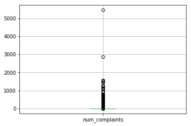

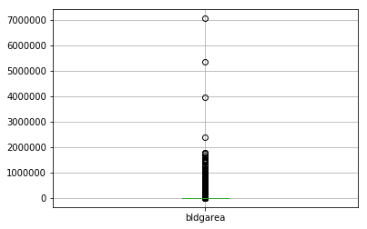

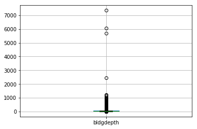

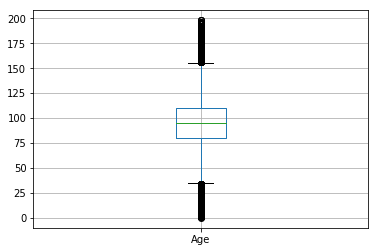

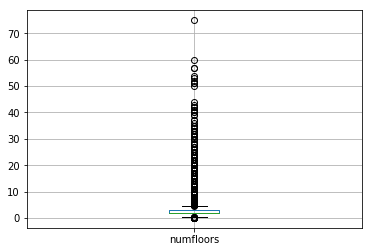

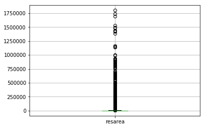

```python
for column in buildings_df:
    plt.figure()
    buildings_df.boxplot([column])
```

```python
buildings_df = buildings_df[buildings_df.num_complaints <= 1000]
buildings_df = buildings_df[buildings_df.bldgarea <= 2000000]
buildings_df = buildings_df[buildings_df.bldgdepth <= 2000]
buildings_df = buildings_df[buildings_df.resarea <= 1000000]
buildings_df.describe()
```

|  | num_complaints | bldgarea | bldgdepth | Age | numfloors | resarea |
| --- | --- | --- | --- | --- | --- | --- |
| count | 262295.000000 | 2.622950e+05 | 262295.000000 | 262295.000000 | 262295.000000 | 262295.000000 |
| mean | 1.840081 | 5.249603e+03 | 52.100731 | 88.705694 | 2.426893 | 3693.692019 |
| std | 15.918981 | 2.269316e+04 | 25.006224 | 29.997665 | 1.156399 | 15960.850616 |
| min | 0.000000 | 1.500000e+01 | 0.000000 | 1.000000 | 0.000000 | 0.000000 |
| 25% | 0.000000 | 1.768000e+03 | 40.000000 | 80.000000 | 2.000000 | 1360.000000 |
| 50% | 0.000000 | 2.445000e+03 | 48.000000 | 95.000000 | 2.000000 | 2000.000000 |
| 75% | 0.000000 | 3.420000e+03 | 59.000000 | 110.000000 | 3.000000 | 2740.000000 |
| max | 959.000000 | 1.785288e+06 | 1222.000000 | 198.000000 | 75.000000 | 997720.000000 |

```python
scaler = MinMaxScaler()
scaled_buildings = scaler.fit_transform(buildings_df)
scaled_buildings = pd.DataFrame(scaled_buildings, columns=["num_complaints", "bldgarea", "bldgdepth", "Age","numfloors", "resarea"])
scaled_buildings.head(15)
```

|  | num_complaints | bldgarea | bldgdepth | Age | numfloors | resarea |
| --- | --- | --- | --- | --- | --- | --- |
| 0 | 0.000000 | 0.002035 | 0.042553 | 0.446701 | 0.040000 | 0.002604 |
| 1 | 0.000000 | 0.001568 | 0.054828 | 0.502538 | 0.026667 | 0.002820 |
| 2 | 0.000000 | 0.000537 | 0.022095 | 0.502538 | 0.026667 | 0.000975 |
| 3 | 0.000000 | 0.000517 | 0.022095 | 0.502538 | 0.026667 | 0.000940 |
| 4 | 0.000000 | 0.000517 | 0.022095 | 0.502538 | 0.026667 | 0.000940 |
| 5 | 0.000000 | 0.000517 | 0.022095 | 0.502538 | 0.026667 | 0.000940 |
| 6 | 0.000000 | 0.000544 | 0.022095 | 0.502538 | 0.026667 | 0.000988 |
| 7 | 0.000000 | 0.000406 | 0.022913 | 0.502538 | 0.013333 | 0.000742 |
| 8 | 0.000000 | 0.001000 | 0.029460 | 0.324873 | 0.026667 | 0.001443 |
| 9 | 0.000000 | 0.000854 | 0.032733 | 0.401015 | 0.013333 | 0.000882 |
| 10 | 0.000000 | 0.000713 | 0.044190 | 0.324873 | 0.013333 | 0.001291 |
| 11 | 0.001043 | 0.001874 | 0.068740 | 0.553299 | 0.026667 | 0.001684 |
| 12 | 0.000000 | 0.001297 | 0.024550 | 0.598985 | 0.040000 | 0.002335 |
| 13 | 0.002086 | 0.001920 | 0.043372 | 0.324873 | 0.026667 | 0.002510 |
| 14 | 0.000000 | 0.001920 | 0.043372 | 0.324873 | 0.026667 | 0.002510 |

```python
bldg_corr = scaled_buildings.corr(method="pearson")
bldg_corr
```

|  | num_complaints | bldgarea | bldgdepth | Age | numfloors | resarea |
| --- | --- | --- | --- | --- | --- | --- |
| num_complaints | 1.000000 | 0.148073 | 0.155981 | 0.011190 | 0.186633 | 0.214072 |
| bldgarea | 0.148073 | 1.000000 | 0.427856 | -0.091327 | 0.508921 | 0.730750 |
| bldgdepth | 0.155981 | 0.427856 | 1.000000 | -0.081684 | 0.193341 | 0.234073 |
| Age | 0.011190 | -0.091327 | -0.081684 | 1.000000 | -0.061580 | -0.081009 |
| numfloors | 0.186633 | 0.508921 | 0.193341 | -0.061580 | 1.000000 | 0.555567 |
| resarea | 0.214072 | 0.730750 | 0.234073 | -0.081009 | 0.555567 | 1.000000 |

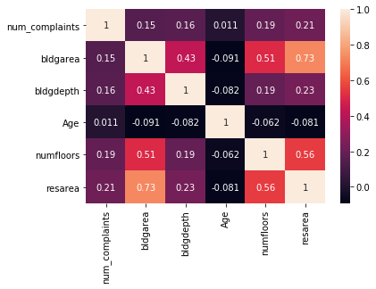

```python
sns.heatmap(bldg_corr, annot=True)
plt.show()
```

**There seems to be no significant correlation between the number of complaints and age, area, depth and how tall a building is.**

Let's see if anything changes when we drop addresses with no complaints...

```python
buildings_nocomplaint = scaled_buildings[scaled_buildings.num_complaints != 0]
buildings_nocomplaint.head()
```

|  | num_complaints | bldgarea | bldgdepth | Age | numfloors | resarea |
| --- | --- | --- | --- | --- | --- | --- |
| 11 | 0.001043 | 0.001874 | 0.068740 | 0.553299 | 0.026667 | 0.001684 |
| 13 | 0.002086 | 0.001920 | 0.043372 | 0.324873 | 0.026667 | 0.002510 |
| 17 | 0.008342 | 0.002411 | 0.058920 | 0.451777 | 0.040000 | 0.003031 |
| 43 | 0.001043 | 0.002075 | 0.045008 | 0.451777 | 0.026667 | 0.002416 |
| 44 | 0.004171 | 0.001479 | 0.036825 | 0.553299 | 0.040000 | 0.001774 |

```python
bldg_corr1 = buildings_nocomplaint.corr(method="pearson")
bldg_corr1
```

|  | num_complaints | bldgarea | bldgdepth | Age | numfloors | resarea |
| --- | --- | --- | --- | --- | --- | --- |
| num_complaints | 1.000000 | 0.226969 | 0.279433 | -0.002579 | 0.249354 | 0.281980 |
| bldgarea | 0.226969 | 1.000000 | 0.474511 | -0.157527 | 0.662577 | 0.853335 |
| bldgdepth | 0.279433 | 0.474511 | 1.000000 | -0.070890 | 0.375210 | 0.424971 |
| Age | -0.002579 | -0.157527 | -0.070890 | 1.000000 | -0.163214 | -0.153929 |
| numfloors | 0.249354 | 0.662577 | 0.375210 | -0.163214 | 1.000000 | 0.697939 |
| resarea | 0.281980 | 0.853335 | 0.424971 | -0.153929 | 0.697939 | 1.000000 |

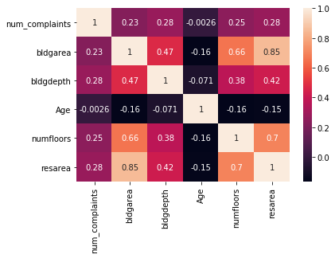

```python
sns.heatmap(bldg_corr1, annot=True)
plt.show()
```

**Still we don't have any meaningful correlation...**

Here we recourse to domain knowledge again...

In the dataset file, it says; "*If the NUMBER OF FLOORS is zero and the NUMBER OF BUILDINGS is greater than zero, then NUMBER OF FLOORS is not available for the tax lot. If the NUMBER OF FLOORS is zero and the NUMBER OF BUILDINGS is zero, then NUMBER OF FLOORS is not applicable for the tax lot.*"

Plus, there's also an explanation about Residential Area which indicates ; "*A RESIDENTIAL FLOOR AREA of zero can mean it is either not available or not applicable*".

```python
buildings_taxlot = buildings_nocomplaint[buildings_nocomplaint.numfloors != 0]
buildings_taxlot = buildings_nocomplaint[buildings_nocomplaint.resarea != 0]
buildings_taxlot.head()
```

|  | num_complaints | bldgarea | bldgdepth | Age | numfloors | resarea |
| --- | --- | --- | --- | --- | --- | --- |
| 11 | 0.001043 | 0.001874 | 0.068740 | 0.553299 | 0.026667 | 0.001684 |
| 13 | 0.002086 | 0.001920 | 0.043372 | 0.324873 | 0.026667 | 0.002510 |
| 17 | 0.008342 | 0.002411 | 0.058920 | 0.451777 | 0.040000 | 0.003031 |
| 43 | 0.001043 | 0.002075 | 0.045008 | 0.451777 | 0.026667 | 0.002416 |
| 44 | 0.004171 | 0.001479 | 0.036825 | 0.553299 | 0.040000 | 0.001774 |

```python
bldg_corr2 = buildings_taxlot.corr(method="pearson")
bldg_corr2
```

|  | num_complaints | bldgarea | bldgdepth | Age | numfloors | resarea |
| --- | --- | --- | --- | --- | --- | --- |
| num_complaints | 1.000000 | 0.261314 | 0.317809 | -0.005110 | 0.256688 | 0.281350 |
| bldgarea | 0.261314 | 1.000000 | 0.453035 | -0.158068 | 0.695690 | 0.965472 |
| bldgdepth | 0.317809 | 0.453035 | 1.000000 | -0.059660 | 0.409457 | 0.479627 |
| Age | -0.005110 | -0.158068 | -0.059660 | 1.000000 | -0.166534 | -0.159999 |
| numfloors | 0.256688 | 0.695690 | 0.409457 | -0.166534 | 1.000000 | 0.719398 |
| resarea | 0.281350 | 0.965472 | 0.479627 | -0.159999 | 0.719398 | 1.000000 |

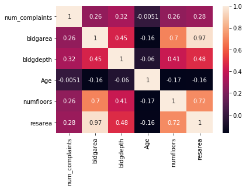

```python
sns.heatmap(bldg_corr2, annot=True)
plt.show()
```

**We can confidently conclude that there are no strong correlations between the number of complaints and age, area, depth and how tall a building is.**

### Predictive Model

- **Prediction of number of Heat/Hot Water complaints in Brooklyn for the next three years.**
- **Prediction of time required in terms of days to resolve the Heat/Hot Water complaint in Brooklyn.**

```python
df_Brook_Heat.head()
```

|  | created_date | unique_key | complaint_type | incident_zip | incident_address | street_name | address_type | city | resolution_description | borough | latitude | longitude | closed_date | location_type | status | Open | Closed | In Progress |
| --- | --- | --- | --- | --- | --- | --- | --- | --- | --- | --- | --- | --- | --- | --- | --- | --- | --- | --- |
| 13 | 2020-03-28 17:58:28 | 45911011 | HEAT/HOT WATER | 11217.0 | 67 HANSON PLACE | HANSON PLACE | ADDRESS | BROOKLYN | The following complaint conditions are still o... | BROOKLYN | 40.685452 | -73.974897 | NaT | RESIDENTIAL BUILDING | Open | 1 | 0 | 0 |
| 15 | 2020-03-28 15:55:54 | 45910554 | HEAT/HOT WATER | 11213.0 | 500 MONTGOMERY STREET | MONTGOMERY STREET | ADDRESS | BROOKLYN | The complaint you filed is a duplicate of a co... | BROOKLYN | 40.665261 | -73.948505 | NaT | RESIDENTIAL BUILDING | Open | 1 | 0 | 0 |
| 19 | 2020-03-28 21:31:51 | 45910648 | HEAT/HOT WATER | 11211.0 | 218 SOUTH 3 STREET | SOUTH 3 STREET | ADDRESS | BROOKLYN | The following complaint conditions are still o... | BROOKLYN | 40.711210 | -73.958973 | NaT | RESIDENTIAL BUILDING | Open | 1 | 0 | 0 |
| 21 | 2020-03-28 15:10:07 | 45911006 | HEAT/HOT WATER | 11214.0 | 2160 84 STREET | 84 STREET | ADDRESS | BROOKLYN | The complaint you filed is a duplicate of a co... | BROOKLYN | 40.603652 | -73.993565 | NaT | RESIDENTIAL BUILDING | Open | 1 | 0 | 0 |
| 24 | 2020-03-28 22:15:22 | 45911132 | HEAT/HOT WATER | 11213.0 | 365 LINCOLN PLACE | LINCOLN PLACE | ADDRESS | BROOKLYN | The complaint you filed is a duplicate of a co... | BROOKLYN | 40.673045 | -73.964037 | NaT | RESIDENTIAL BUILDING | Open | 1 | 0 | 0 |

```python
df_Brook_Heat.shape
```

```
(672767, 18)
```

```python
def datetimeprocess(df):
    df['Resolution_Time'] = (df['closed_date'] - df['created_date']).dt.days
    df = df[df['Resolution_Time'].notnull()]
    df1 = df[df['closed_date'] >= df['created_date']]
    df1['Day of Week'] = df1['created_date'].dt.dayofweek
    df1['Day of Month'] = df1['created_date'].dt.day
    df1['Month'] = df1['created_date'].dt.month
    df1['Year'] = df1['created_date'].dt.year
    return df1
```

```python
df_BK_Heat = datetimeprocess(df_Brook_Heat)
df_BK_Heat.shape
```

```
(668523, 23)
```

```python
df_BK_Heat.head()
```

|  | created_date | unique_key | complaint_type | incident_zip | incident_address | street_name | address_type | city | resolution_description | borough | ... | location_type | status | Open | Closed | In Progress | Resolution_Time | Day of Week | Day of Month | Month | Year |
| --- | --- | --- | --- | --- | --- | --- | --- | --- | --- | --- | --- | --- | --- | --- | --- | --- | --- | --- | --- | --- | --- |
| 554 | 2020-03-28 06:11:30 | 45908784 | HEAT/HOT WATER | 11237.0 | 1713 HARMAN STREET | HARMAN STREET | ADDRESS | Ridgewood | The Department of Housing Preservation and Dev... | BROOKLYN | ... | RESIDENTIAL BUILDING | Closed | 0 | 1 | 0 | 0.0 | 5 | 28 | 3 | 2020 |
| 761 | 2020-03-28 06:41:41 | 45908392 | HEAT/HOT WATER | 11211.0 | 220 PENN STREET | PENN STREET | ADDRESS | BROOKLYN | The Department of Housing Preservation and Dev... | BROOKLYN | ... | RESIDENTIAL BUILDING | Closed | 0 | 1 | 0 | 0.0 | 5 | 28 | 3 | 2020 |
| 857 | 2020-03-28 07:43:22 | 45909576 | HEAT/HOT WATER | 11237.0 | 1713 HARMAN STREET | HARMAN STREET | ADDRESS | Ridgewood | The Department of Housing Preservation and Dev... | BROOKLYN | ... | RESIDENTIAL BUILDING | Closed | 0 | 1 | 0 | 0.0 | 5 | 28 | 3 | 2020 |
| 894 | 2020-03-04 18:10:01 | 45756289 | HEAT/HOT WATER | 11226.0 | 2815 BEVERLY ROAD | BEVERLY ROAD | ADDRESS | BROOKLYN | The Department of Housing Preservation and Dev... | BROOKLYN | ... | RESIDENTIAL BUILDING | Closed | 0 | 1 | 0 | 1.0 | 2 | 4 | 3 | 2020 |
| 895 | 2020-03-04 01:16:06 | 45756266 | HEAT/HOT WATER | 11226.0 | 55 LENOX ROAD | LENOX ROAD | ADDRESS | BROOKLYN | The Department of Housing Preservation and Dev... | BROOKLYN | ... | RESIDENTIAL BUILDING | Closed | 0 | 1 | 0 | 0.0 | 2 | 4 | 3 | 2020 |

5 rows × 23 columns

```python
round(df_BK_Heat.Resolution_Time.mean(), 2)
```

```
3.1
```

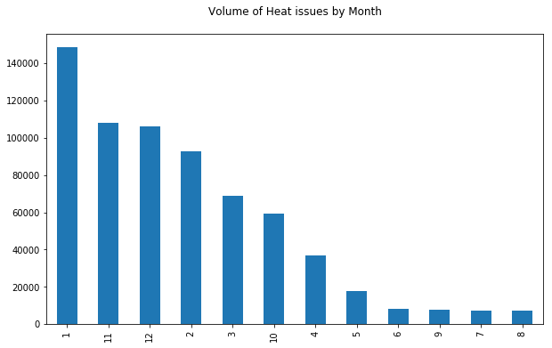

```python
df_BK_Heat['Month'].value_counts().plot(kind = 'bar',figsize=(10,6), title = 'Volume of Heat issues by Month\n')
```

As might be expected, Heat issues are most common in the months from November to February.

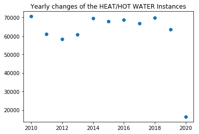

```python
year_BK = df_Brook_Heat.groupby(df_Brook_Heat.created_date.dt.year)

plt.scatter(year_BK.count().index ,year_BK.count().complaint_type)
plt.title("Yearly changes of the HEAT/HOT WATER Instances")
plt.show()
```

```python
year_BK.count().complaint_type
```

```
created_date
2010    70564
2011    60905
2012    58263
2013    60724
2014    69470
2015    67914
2016    68633
2017    66723
2018    69884
2019    63363
2020    16324
Name: complaint_type, dtype: int64
```

Since years 2010 and 2020 data don't cover whole corresponding year's data, I'll ignore them.

```python
df_BK_Heat = df_BK_Heat.loc[(df_BK_Heat.Year < 2020) & (df_BK_Heat.Year > 2010)]
df_BK_Heat.shape
```

```
(582236, 23)
```

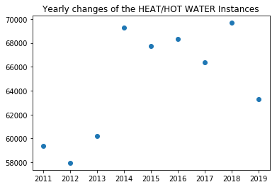

```python
year_BK = df_BK_Heat.groupby(df_BK_Heat.created_date.dt.year)

plt.scatter(year_BK.count().index ,year_BK.count().complaint_type)
plt.title("Yearly changes of the HEAT/HOT WATER Instances")
plt.show()
```

```python
year_BK.count().complaint_type
```

```
created_date
2011    59347
2012    57958
2013    60205
2014    69251
2015    67743
2016    68353
2017    66391
2018    69680
2019    63308
Name: complaint_type, dtype: int64
```

```python
X = year_BK.count().index
y = year_BK.count().complaint_type
X = [X.tolist()]
X
```

```
[[2011, 2012, 2013, 2014, 2015, 2016, 2017, 2018, 2019]]
```

```python
X = np.asarray(X)
X = X.reshape(-1, 1)
X
```

```
array([[2011],
       [2012],
       [2013],
       [2014],
       [2015],
       [2016],
       [2017],
       [2018],
       [2019]])
```

```python
lin = LinearRegression()
lin.fit(X, y)
```

```
LinearRegression(copy_X=True, fit_intercept=True, n_jobs=None,
         normalize=False)
```

```python
poly = PolynomialFeatures(degree = 2)
X_poly = poly.fit_transform(X)

poly.fit(X_poly, y)
lin2 = LinearRegression()
lin2.fit(X_poly, y)
```

```
LinearRegression(copy_X=True, fit_intercept=True, n_jobs=None,
         normalize=False)
```

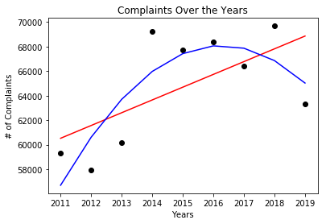

```python
plt.scatter(X, y, color = 'black')

plt.plot(X, lin.predict(X), color = 'red')
plt.plot(X, lin2.predict(X_poly), color = 'blue')
plt.title('Complaints Over the Years')
plt.xlabel('Years')
plt.ylabel('# of Complaints')

plt.show()
```

```python
linpred20 = lin.predict([[2020]])
linpred21 = lin.predict([[2021]])
linpred22 = lin.predict([[2022]])

print('Predicted Heat Complaints in 2020 as regards Linear Regression: ', int(linpred20))
print('Predicted Heat Complaints in 2021 as regards Linear Regression: ', int(linpred21))
print('Predicted Heat Complaints in 2022 as regards Linear Regression: ', int(linpred22))
```

```
Predicted Heat Complaints in 2020 as regards Linear Regression:  69899
Predicted Heat Complaints in 2021 as regards Linear Regression:  70941
Predicted Heat Complaints in 2022 as regards Linear Regression:  71982
```

```python
lin2pred20 = lin2.predict(poly.fit_transform([[2020]]))
lin2pred21 = lin2.predict(poly.fit_transform([[2021]]))
lin2pred22 = lin2.predict(poly.fit_transform([[2022]]))

print('Predicted Heat Complaints in 2020 as regards Polynomial Regression: ', int(lin2pred20))
print('Predicted Heat Complaints in 2021 as regards Polynomial Regression: ', int(lin2pred21))
print('Predicted Heat Complaints in 2022 as regards Polynomial Regression: ', int(lin2pred22))
```

```
Predicted Heat Complaints in 2020 as regards Polynomial Regression:  62378
Predicted Heat Complaints in 2021 as regards Polynomial Regression:  58906
Predicted Heat Complaints in 2022 as regards Polynomial Regression:  54614
```

While considering Linear Regression, the number of complaints will rise in the coming years, whereas they will fall according to the Polynomial Regression analysis.

This is a big issue, since we need to allocate resources aligned with our prediction analysis. We have to be sure which of these regression methods will be more precise, so that we can plan the next three years well enough. For that reason, I examined the plot above again and saw that there is a big jump in the year 2014 and there seems to be different factors effecting the number of complaints before and after 2014. In the light of this assumption, I'll redo my analysis taking the period after 2014 into account.

```python
X1 = X[3:]
y1 = y[3:]
X1
```

```
array([[2014],
       [2015],
       [2016],
       [2017],
       [2018],
       [2019]])
```

```python
lin1 = LinearRegression()
lin1.fit(X1, y1)
poly1 = PolynomialFeatures(degree = 2)
X1_poly = poly.fit_transform(X1)

poly1.fit(X1_poly, y1)
lin3 = LinearRegression()
lin3.fit(X1_poly, y1)
```

```
LinearRegression(copy_X=True, fit_intercept=True, n_jobs=None,
         normalize=False)
```

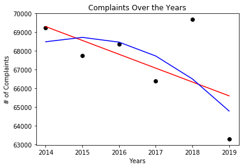

```python
plt.scatter(X1, y1, color = 'black')

plt.plot(X1, lin1.predict(X1), color = 'red')
plt.plot(X1, lin3.predict(X1_poly), color = 'blue')
plt.title('Complaints Over the Years')
plt.xlabel('Years')
plt.ylabel('# of Complaints')

plt.show()
```

```python
lin1pred20 = lin1.predict([[2020]])
lin1pred21 = lin1.predict([[2021]])
lin1pred22 = lin1.predict([[2022]])

print('Predicted Heat Complaints in 2020 as regards Linear Regression: ', int(lin1pred20))
print('Predicted Heat Complaints in 2021 as regards Linear Regression: ', int(lin1pred21))
print('Predicted Heat Complaints in 2022 as regards Linear Regression: ', int(lin1pred22))
```

```
Predicted Heat Complaints in 2020 as regards Linear Regression:  64867
Predicted Heat Complaints in 2021 as regards Linear Regression:  64128
Predicted Heat Complaints in 2022 as regards Linear Regression:  63389
```

```python
lin3pred20 = lin3.predict(poly.fit_transform([[2020]]))
lin3pred21 = lin3.predict(poly.fit_transform([[2021]]))
lin3pred22 = lin3.predict(poly.fit_transform([[2022]]))

print('Predicted Heat Complaints in 2020 as regards Polynomial Regression: ', int(lin3pred20))
print('Predicted Heat Complaints in 2021 as regards Polynomial Regression: ', int(lin3pred21))
print('Predicted Heat Complaints in 2022 as regards Polynomial Regression: ', int(lin3pred22))
```

```
Predicted Heat Complaints in 2020 as regards Polynomial Regression:  62600
Predicted Heat Complaints in 2021 as regards Polynomial Regression:  59917
Predicted Heat Complaints in 2022 as regards Polynomial Regression:  56749
```

Now, we have a better prediction with closer values for 2020. So, we can plan to allocate our resources for 2020 for an expectation of around 65000 complaints.

## Resolution Time Prediction

### Preprocessing:

```python
def getDfSummary(input_data):
    number_nan = input_data.isnull().sum()
    number_distinct = input_data.nunique(dropna=True)
    output_data = pd.DataFrame({'number_nan':number_nan,'number_distinct':number_distinct})
    return output_data
```

```python
getDfSummary(df_BK_Heat)
```

|  | number_nan | number_distinct |
| --- | --- | --- |
| created_date | 0 | 289975 |
| unique_key | 0 | 582236 |
| complaint_type | 0 | 1 |
| incident_zip | 0 | 38 |
| incident_address | 0 | 44944 |
| street_name | 0 | 1299 |
| address_type | 5367 | 1 |
| city | 5422 | 65 |
| resolution_description | 0 | 184 |
| borough | 0 | 1 |
| latitude | 5434 | 44485 |
| longitude | 5434 | 44485 |
| closed_date | 0 | 84695 |
| location_type | 0 | 1 |
| status | 0 | 2 |
| Open | 0 | 2 |
| Closed | 0 | 2 |
| In Progress | 0 | 1 |
| Resolution_Time | 0 | 143 |
| Day of Week | 0 | 7 |
| Day of Month | 0 | 31 |
| Month | 0 | 12 |
| Year | 0 | 9 |

```
array([[<matplotlib.axes._subplots.AxesSubplot object at 0x7f06ebb73470>,
      dtype=object)
```

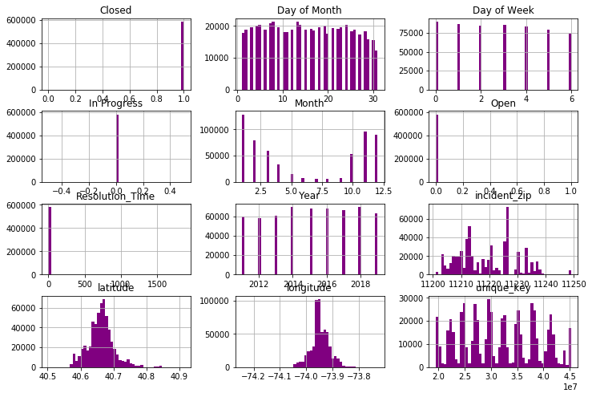

```python
df_BK_Heat.hist(bins=50, figsize = (12,8), color = 'purple')
```

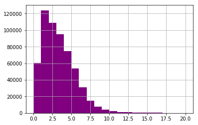

```python
df_BK_Heat['Resolution_Time'].hist(bins = 20, range = [0, 20], color = 'purple')
```

```python
df_BK_Heat.columns
```

```
Index(['created_date', 'unique_key', 'complaint_type', 'incident_zip',
       'incident_address', 'street_name', 'address_type', 'city',
       'resolution_description', 'borough', 'latitude', 'longitude',
       'closed_date', 'location_type', 'status', 'Open', 'Closed',
       'In Progress', 'Resolution_Time', 'Day of Week', 'Day of Month',
       'Month', 'Year'],
      dtype='object')
```

```python
df_model = df_BK_Heat[['incident_zip', 'status','Day of Week','Day of Month','Month', 'Year', 'Resolution_Time']]
dummies = pd.get_dummies(df_BK_Heat['status'])
df_model = pd.concat([df_model, dummies],axis = 1)
df_model = df_model.drop('status',1)
df_model['incident_zip'] = df_model['incident_zip'].astype(int)
df_model['incident_zip']=df_model['incident_zip']-df_model['incident_zip'].min()
df_model['Resolution_Time'] = df_model['Resolution_Time'].astype(int)
```

```python
df_model.describe()
```

|  | incident_zip | Day of Week | Day of Month | Month | Year | Resolution_Time | Closed | Open |
| --- | --- | --- | --- | --- | --- | --- | --- | --- |
| count | 582236.000000 | 582236.000000 | 582236.000000 | 582236.000000 | 582236.000000 | 582236.000000 | 582236.000000 | 582236.000000 |
| mean | 17.940629 | 2.891108 | 15.555656 | 6.085732 | 2015.107317 | 2.948495 | 0.999955 | 0.000045 |
| std | 9.952489 | 1.985818 | 8.736139 | 4.487456 | 2.537347 | 7.397833 | 0.006682 | 0.006682 |
| min | 0.000000 | 0.000000 | 1.000000 | 1.000000 | 2011.000000 | 0.000000 | 0.000000 | 0.000000 |
| 25% | 10.000000 | 1.000000 | 8.000000 | 2.000000 | 2013.000000 | 1.000000 | 1.000000 | 0.000000 |
| 50% | 17.000000 | 3.000000 | 15.000000 | 4.000000 | 2015.000000 | 2.000000 | 1.000000 | 0.000000 |
| 75% | 25.000000 | 5.000000 | 23.000000 | 11.000000 | 2017.000000 | 4.000000 | 1.000000 | 0.000000 |
| max | 48.000000 | 6.000000 | 31.000000 | 12.000000 | 2019.000000 | 1868.000000 | 1.000000 | 1.000000 |

```python
df_model.Resolution_Time.value_counts()
```

```
1       124049
2       108796
3        95392
4        74530
0        60597
5        53775
6        31322
7        15102
8         7764
9         4157
10        2326
11        1302
12         843
13         561
14         426
```

[output cut: 47 more lines]

Since the data is highly imbalanced I'm going to remove outliers. Most of the complaints are resolved within two weeks.

```python
df_model.drop(df_model[df_model.Resolution_Time > 15].index, inplace=True)
df_model.Resolution_Time.value_counts()
```

```
1     124049
2     108796
3      95392
4      74530
0      60597
5      53775
6      31322
7      15102
8       7764
9       4157
10      2326
11      1302
12       843
13       561
14       426
15       273
Name: Resolution_Time, dtype: int64
```

```python
bins = [0, 3, 10, 15]
group_names = ["prompt", "within 10 days", "more than 10 days"]
df_model['categories'] = pd.cut(df_model['Resolution_Time'], bins, include_lowest = True, labels = group_names)
df_model.describe()
```

|  | incident_zip | Day of Week | Day of Month | Month | Year | Resolution_Time | Closed | Open |
| --- | --- | --- | --- | --- | --- | --- | --- | --- |
| count | 581215.000000 | 581215.000000 | 581215.000000 | 581215.000000 | 581215.000000 | 581215.000000 | 581215.000000 | 581215.000000 |
| mean | 17.936349 | 2.891095 | 15.557603 | 6.083833 | 2015.106962 | 2.844099 | 0.999959 | 0.000041 |
| std | 9.944885 | 1.985814 | 8.735289 | 4.489012 | 2.538006 | 2.157602 | 0.006426 | 0.006426 |
| min | 0.000000 | 0.000000 | 1.000000 | 1.000000 | 2011.000000 | 0.000000 | 0.000000 | 0.000000 |
| 25% | 10.000000 | 1.000000 | 8.000000 | 2.000000 | 2013.000000 | 1.000000 | 1.000000 | 0.000000 |
| 50% | 17.000000 | 3.000000 | 15.000000 | 4.000000 | 2015.000000 | 2.000000 | 1.000000 | 0.000000 |
| 75% | 25.000000 | 5.000000 | 23.000000 | 11.000000 | 2017.000000 | 4.000000 | 1.000000 | 0.000000 |
| max | 48.000000 | 6.000000 | 31.000000 | 12.000000 | 2019.000000 | 15.000000 | 1.000000 | 1.000000 |

```python
getDfSummary(df_model)
```

|  | number_nan | number_distinct |
| --- | --- | --- |
| incident_zip | 0 | 38 |
| Day of Week | 0 | 7 |
| Day of Month | 0 | 31 |
| Month | 0 | 12 |
| Year | 0 | 9 |
| Resolution_Time | 0 | 16 |
| Closed | 0 | 2 |
| Open | 0 | 2 |
| categories | 0 | 3 |

```python
Xrt = df_model[['incident_zip', 'Day of Week', 'Day of Month','Month',
        'Year']]
yrt = df_model.categories
Xrt.shape, yrt.shape
```

```
((581215, 5), (581215,))
```

### Model Design and Selection

#### Model Selection:

I will compare the performances of 6 predictive models:

- LogisticRegression
- KNeighborsClassifier
- LinearSVC
- MultinomialNB
- DecisionTreeClassifier
- RandomForestClassifier

```python
X_train, X_test, y_train, y_test = train_test_split(Xrt, yrt, test_size = 0.25, random_state = 0)
X_train.shape, X_test.shape, y_train.shape, y_test.shape
```

```
((435911, 5), (145304, 5), (435911,), (145304,))
```

```python
models = [LogisticRegression(), KNeighborsClassifier(), LinearSVC(), MultinomialNB(), DecisionTreeClassifier(), RandomForestClassifier(n_jobs=-1)]
```

```python
modelScores = []
for model in models:
    print(model)
    model.fit(X_train, y_train)
    y_pred = model.predict(X_test)
    score = accuracy_score(y_test, y_pred)
    print(score)
    modelScores.append([model, score])
```

```
LogisticRegression(C=1.0, class_weight=None, dual=False, fit_intercept=True,
          intercept_scaling=1, max_iter=100, multi_class='warn',
          n_jobs=None, penalty='l2', random_state=None, solver='warn',
          tol=0.0001, verbose=0, warm_start=False)
0.5863431151241535
KNeighborsClassifier(algorithm='auto', leaf_size=30, metric='minkowski',
           metric_params=None, n_jobs=None, n_neighbors=5, p=2,
           weights='uniform')
0.7256923415735286
LinearSVC(C=1.0, class_weight=None, dual=True, fit_intercept=True,
     intercept_scaling=1, loss='squared_hinge', max_iter=1000,
     multi_class='ovr', penalty='l2', random_state=None, tol=0.0001,
     verbose=0)
0.4906265484776744
MultinomialNB(alpha=1.0, class_prior=None, fit_prior=True)
0.5739828222209987
DecisionTreeClassifier(class_weight=None, criterion='gini', max_depth=None,
            max_features=None, max_leaf_nodes=None,
            min_impurity_decrease=0.0, min_impurity_split=None,
            min_samples_leaf=1, min_samples_split=2,
            min_weight_fraction_leaf=0.0, presort=False, random_state=None,
            splitter='best')
0.7401379177448659
RandomForestClassifier(bootstrap=True, class_weight=None, criterion='gini',
            max_depth=None, max_features='auto', max_leaf_nodes=None,
            min_impurity_decrease=0.0, min_impurity_split=None,
            min_samples_leaf=1, min_samples_split=2,
            min_weight_fraction_leaf=0.0, n_estimators='warn', n_jobs=-1,
            oob_score=False, random_state=None, verbose=0,
            warm_start=False)
0.7418859769861808
```

I will select the best 3 performers to continue...

```python
ranked_models = sorted(modelScores, key=lambda x: x[1], reverse=True)
ranked_models[:3]
```

```
[[RandomForestClassifier(bootstrap=True, class_weight=None, criterion='gini',
              max_depth=None, max_features='auto', max_leaf_nodes=None,
              min_impurity_decrease=0.0, min_impurity_split=None,
              min_samples_leaf=1, min_samples_split=2,
              min_weight_fraction_leaf=0.0, n_estimators=10, n_jobs=-1,
              oob_score=False, random_state=None, verbose=0,
              warm_start=False), 0.7418859769861808],
 [DecisionTreeClassifier(class_weight=None, criterion='gini', max_depth=None,
              max_features=None, max_leaf_nodes=None,
              min_impurity_decrease=0.0, min_impurity_split=None,
              min_samples_leaf=1, min_samples_split=2,
              min_weight_fraction_leaf=0.0, presort=False, random_state=None,
              splitter='best'), 0.7401379177448659],
 [KNeighborsClassifier(algorithm='auto', leaf_size=30, metric='minkowski',
             metric_params=None, n_jobs=None, n_neighbors=5, p=2,
             weights='uniform'), 0.7256923415735286]]
```

#### Hyperparameter Tuning

I will create dictionaries to be utilized in Grid Search and then try to build a pipeline for Hyperparameter Tuning:

- classifiers: classifier label and classifier object
- parameters: hyper-parameter grid for each classifier

```python
classifiers = {}
classifiers.update({"KNN": KNeighborsClassifier()})
classifiers.update({"DTC": DecisionTreeClassifier()})
classifiers.update({"RFC": RandomForestClassifier()})
```

```python
parameters = {}

parameters.update({"KNN": {
                            "classifier__n_neighbors": list(range(1, 21)),
                            "classifier__algorithm": ["auto", "ball_tree", "kd_tree"]
                             }})
parameters.update({"DTC": {
                            "classifier__criterion" :["gini", "entropy"],
                            "classifier__max_features": ["auto", "sqrt", "log2"],
                            "classifier__max_depth" : [4, 5, 6, 7, 8],
                            "classifier__min_samples_split": [0.005, 0.01, 0.05, 0.10]
                             }})
parameters.update({"RFC": {
                            "classifier__n_estimators": [100],
                            "classifier__max_features": ["auto", "sqrt", "log2"],
                            "classifier__max_depth" : [4, 5, 6, 7, 8],
                            "classifier__min_samples_split": [0.005, 0.01, 0.05, 0.10],
                            "classifier__criterion" :["gini", "entropy"],
                            "classifier__n_jobs": [-1]
                             }})
```

```python
# results = {}

# for classifier_label, classifier in classifiers.items():
#    print(f"Now tuning {classifier_label}. This will take a while.")

#    scaler = StandardScaler()
#    steps = [("scaler", scaler), ("classifier", classifier)]
#    pipeline = Pipeline(steps = steps, memory = "cache_folder")

#    param_grid = parameters[classifier_label]

#   gscv = GridSearchCV(pipeline, param_grid, cv = 4,  n_jobs= -1, verbose = 1, scoring = "accuracy")
#   gscv.fit(X_train, y_train)

#   best_params = gscv.best_params_
#   best_score = gscv.best_score_

#   tuned_params = {item[12:]: best_params[item] for item in best_params}
#   classifier.set_params(**tuned_params)

#   y_pred = gscv.predict(X_test)
#   test_score = accuracy_score(y_test, y_pred)

#   print(classifier_label, ": " /n, confusion_matrix(y_test, y_pred))
#   print(classifier_label, ": " /n, classification_report(y_test, y_pred))

#   result = {"Classifier": gscv,
#             "Best Parameters": best_params,
#             "Training Score": best_score,
#             "Test Score": test_score}
#   results.update({classifier_label: result})
```

Ideally, I would run the piece of code in the upper cell to perform the Grid Search for tuning hyperparameters for three selected models. However, after waiting for hours and calibrating the code for faster performance, I still get the following output;

"*Now tuning KNN. This will take a while. Fitting 4 folds for each of 60 candidates, totalling 240 fits [Parallel(n_jobs=-1)]: Using backend LokyBackend with 2 concurrent workers. [Parallel(n_jobs=-1)]: Done 46 tasks | elapsed: 128.3min*"

**This tells me, with the resources and the computational power I have, it will take more than 50 hours to complete the task. So for the purposes of this assignment, I decided to leave the code to show the ideal way of doing, and proceed with the Random Forest Algorithm, which I believe is the best model among these three...**

```python
Xrt.describe()
```

|  | incident_zip | Day of Week | Day of Month | Month | Year |
| --- | --- | --- | --- | --- | --- |
| count | 581215.000000 | 581215.000000 | 581215.000000 | 581215.000000 | 581215.000000 |
| mean | 17.936349 | 2.891095 | 15.557603 | 6.083833 | 2015.106962 |
| std | 9.944885 | 1.985814 | 8.735289 | 4.489012 | 2.538006 |
| min | 0.000000 | 0.000000 | 1.000000 | 1.000000 | 2011.000000 |
| 25% | 10.000000 | 1.000000 | 8.000000 | 2.000000 | 2013.000000 |
| 50% | 17.000000 | 3.000000 | 15.000000 | 4.000000 | 2015.000000 |
| 75% | 25.000000 | 5.000000 | 23.000000 | 11.000000 | 2017.000000 |
| max | 48.000000 | 6.000000 | 31.000000 | 12.000000 | 2019.000000 |

```python
Xrt = StandardScaler().fit_transform(Xrt)
X_train, X_test, y_train, y_test = train_test_split(Xrt, yrt, test_size = 0.25, random_state = 0)
X_train.shape, X_test.shape, y_train.shape, y_test.shape
```

```
((435911, 5), (145304, 5), (435911,), (145304,))
```

```python
param_grid = {
    'n_estimators': [100],
    'max_features': ['auto', 'sqrt', 'log2'],
    'max_depth' : [8, 10, 12],
    'criterion' :['gini', 'entropy']
}
grid = GridSearchCV(RandomForestClassifier(random_state = 0), param_grid = param_grid, cv = 4, n_jobs= -1, verbose = 1, refit = True, scoring = "accuracy")
grid.fit(X_train, y_train)
y_pred = grid.predict(X_test)
```

```
Fitting 4 folds for each of 18 candidates, totalling 72 fits
```

```
[Parallel(n_jobs=-1)]: Using backend LokyBackend with 2 concurrent workers.
[Parallel(n_jobs=-1)]: Done  46 tasks      | elapsed: 23.4min
[Parallel(n_jobs=-1)]: Done  72 out of  72 | elapsed: 37.3min finished
```

```python
print("Best cross-validation accuracy: {:.2f}".format(grid.best_score_))
print("Test set score: {:.2f}".format(grid.score(X_test, y_test)))
print("Best parameters: {}".format(grid.best_params_))
```

```
Best cross-validation accuracy: 0.74
Test set score: 0.75
Best parameters: {'criterion': 'gini', 'max_depth': 12, 'max_features': 'auto', 'n_estimators': 100}
```

```python
rfc = grid.best_estimator_
print("Best estimator:\n{}".format(rfc))
```

```
Best estimator:
RandomForestClassifier(bootstrap=True, class_weight=None, criterion='gini',
            max_depth=12, max_features='auto', max_leaf_nodes=None,
            min_impurity_decrease=0.0, min_impurity_split=None,
            min_samples_leaf=1, min_samples_split=2,
            min_weight_fraction_leaf=0.0, n_estimators=100, n_jobs=None,
            oob_score=False, random_state=0, verbose=0, warm_start=False)
```

```python
cm = confusion_matrix(y_test, y_pred)
cm = cm.astype('float') / cm.sum(axis=1)[:, np.newaxis]
print(cm)
```

```
[[1.84331797e-02 4.66589862e-01 5.14976959e-01]
 [2.05475934e-05 8.56362049e-01 1.43617404e-01]
 [6.36929152e-05 4.67229995e-01 5.32706312e-01]]
```

[figure not shown]

```python
import itertools
cmap = plt.cm.Blues
plt.imshow(cm, interpolation = 'nearest', cmap = cmap)
plt.title('Confusion matrix')
plt.colorbar()
tick_marks = np.arange(len(group_names))
plt.xticks(tick_marks, group_names, rotation = 45)
plt.yticks(tick_marks, group_names)

fmt = '.2f'
thresh = cm.max() / 2.
for i, j in itertools.product(range(cm.shape[0]), range(cm.shape[1])):
    plt.text(j, i, format(cm[i, j], fmt),
                 horizontalalignment="center",
                 color="white" if cm[i, j] > thresh else "black")

plt.tight_layout()
plt.ylabel('True label')
plt.xlabel('Predicted label')
plt.show()
```

```python
print(classification_report(y_test, y_pred))
```

```
                   precision    recall  f1-score   support

more than 10 days       0.76      0.02      0.04       868
           prompt       0.79      0.86      0.82     97335
   within 10 days       0.63      0.53      0.58     47101

        micro avg       0.75      0.75      0.75    145304
        macro avg       0.73      0.47      0.48    145304
     weighted avg       0.74      0.75      0.74    145304
```

### Conclusion

We can see from the above confusion matrix and the classification report that Random Forest model is doing fairly good for the first two classes of output. However, because of lack of data points for "more than 10 days", the output show up wrong for third class.

The performance may be improved by performing PCA and adding the "Descriptor" variable which exists in the original NYC 311 Dataset, and employing "one hot encoder" on that variable. We would get a more robust model if we have had more compuatational power which would enable us to perform a broader grid search (code above).